# Spotify dataset Tracks DB

## About Dataset

### Context

I just wanted to analyze the behavior between valence and all the measures that Spotify API gives so I got approximately 10,000 per genre. There are 26 genres so it is a total of 232,725 tracks.

### Content

This is the explanation of every measure: https://developer.spotify.com/documentation/web-api/reference/tracks/get-audio-features/

### Acknowledgements

I want to say thanks to https://www.kaggle.com/tomigelo because I used his code to get these tracks. There is the code: https://github.com/tgel0/spotify-data

```python
import pandas as pd
import matplotlib.pyplot as plt
import seaborn as sns
```

```python
df = pd.read_csv("SpotifyFeatures.csv")
df.head(10)
```

|  | genre | artist_name | track_name | track_id | popularity | acousticness | danceability | duration_ms | energy | instrumentalness | key | liveness | loudness | mode | speechiness | tempo | time_signature | valence |
| --- | --- | --- | --- | --- | --- | --- | --- | --- | --- | --- | --- | --- | --- | --- | --- | --- | --- | --- |
| 0 | Movie | Henri Salvador | C'est beau de faire un Show | 0BRjO6ga9RKCKjfDqeFgWV | 0 | 0.61100 | 0.389 | 99373 | 0.9100 | 0.00000 | C# | 0.3460 | -1.828 | Major | 0.0525 | 166.969 | 4/4 | 0.814 |
| 1 | Movie | Martin & les fées | Perdu d'avance (par Gad Elmaleh) | 0BjC1NfoEOOusryehmNudP | 1 | 0.24600 | 0.590 | 137373 | 0.7370 | 0.00000 | F# | 0.1510 | -5.559 | Minor | 0.0868 | 174.003 | 4/4 | 0.816 |
| 2 | Movie | Joseph Williams | Don't Let Me Be Lonely Tonight | 0CoSDzoNIKCRs124s9uTVy | 3 | 0.95200 | 0.663 | 170267 | 0.1310 | 0.00000 | C | 0.1030 | -13.879 | Minor | 0.0362 | 99.488 | 5/4 | 0.368 |
| 3 | Movie | Henri Salvador | Dis-moi Monsieur Gordon Cooper | 0Gc6TVm52BwZD07Ki6tIvf | 0 | 0.70300 | 0.240 | 152427 | 0.3260 | 0.00000 | C# | 0.0985 | -12.178 | Major | 0.0395 | 171.758 | 4/4 | 0.227 |
| 4 | Movie | Fabien Nataf | Ouverture | 0IuslXpMROHdEPvSl1fTQK | 4 | 0.95000 | 0.331 | 82625 | 0.2250 | 0.12300 | F | 0.2020 | -21.150 | Major | 0.0456 | 140.576 | 4/4 | 0.390 |
| 5 | Movie | Henri Salvador | Le petit souper aux chandelles | 0Mf1jKa8eNAf1a4PwTbizj | 0 | 0.74900 | 0.578 | 160627 | 0.0948 | 0.00000 | C# | 0.1070 | -14.970 | Major | 0.1430 | 87.479 | 4/4 | 0.358 |
| 6 | Movie | Martin & les fées | Premières recherches (par Paul Ventimila, Lori... | 0NUiKYRd6jt1LKMYGkUdnZ | 2 | 0.34400 | 0.703 | 212293 | 0.2700 | 0.00000 | C# | 0.1050 | -12.675 | Major | 0.9530 | 82.873 | 4/4 | 0.533 |
| 7 | Movie | Laura Mayne | Let Me Let Go | 0PbIF9YVD505GutwotpB5C | 15 | 0.93900 | 0.416 | 240067 | 0.2690 | 0.00000 | F# | 0.1130 | -8.949 | Major | 0.0286 | 96.827 | 4/4 | 0.274 |
| 8 | Movie | Chorus | Helka | 0ST6uPfvaPpJLtQwhE6KfC | 0 | 0.00104 | 0.734 | 226200 | 0.4810 | 0.00086 | C | 0.0765 | -7.725 | Major | 0.0460 | 125.080 | 4/4 | 0.765 |
| 9 | Movie | Le Club des Juniors | Les bisous des bisounours | 0VSqZ3KStsjcfERGdcWpFO | 10 | 0.31900 | 0.598 | 152694 | 0.7050 | 0.00125 | G | 0.3490 | -7.790 | Major | 0.0281 | 137.496 | 4/4 | 0.718 |

```python
df.shape
```

```
(232725, 18)
```

```python
df.dtypes
```

```
genre                object
artist_name          object
track_name           object
track_id             object
popularity            int64
acousticness        float64
danceability        float64
duration_ms           int64
energy              float64
instrumentalness    float64
key                  object
liveness            float64
loudness            float64
mode                 object
speechiness         float64
tempo               float64
time_signature       object
valence             float64
dtype: object
```

```python
colonne_object = df.select_dtypes(include=['object']).columns
print(colonne_object)
```

```
Index(['genre', 'artist_name', 'track_name', 'track_id', 'key', 'mode',
       'time_signature'],
      dtype='object')
```

```python
colonne_numeric = df.select_dtypes(include=['float64', 'int64']).columns
print(colonne_numeric)
```

```
Index(['popularity', 'acousticness', 'danceability', 'duration_ms', 'energy',
       'instrumentalness', 'liveness', 'loudness', 'speechiness', 'tempo',
       'valence'],
      dtype='object')
```

```python
df.isnull().sum()
```

```
genre               0
artist_name         0
track_name          1
track_id            0
popularity          0
acousticness        0
danceability        0
duration_ms         0
energy              0
instrumentalness    0
key                 0
liveness            0
loudness            0
mode                0
speechiness         0
tempo               0
time_signature      0
valence             0
dtype: int64
```

```python
#funzione descrittiva

def dataset_describe(df):
    # Numero di osservazioni e colonne
    num_osservazioni, num_colonne = df.shape

    # Nomi delle colonne
    nomi_colonne = df.columns.tolist()

    # Colonne di tipo object e numeriche
    colonne_object = df.select_dtypes(include=['object']).columns
    colonne_numeriche = df.select_dtypes(include=['float64', 'int64']).columns

    # Valori nulli
    valori_nulli = df.isnull().sum()

    # Stampa delle informazioni
    print(f"Numero di osservazioni: {num_osservazioni}")
    print(f"Numero di colonne: {num_colonne}")
    print(f"Nomi delle colonne: {nomi_colonne}")
    print(f"Numero di colonne di tipo object: {len(colonne_object)}")
    print(f"Numero di colonne numeriche: {len(colonne_numeriche)}")
    print("\nValori nulli per colonna:")
    print(valori_nulli)
```

```python
dataset_describe(df)
```

```
Numero di osservazioni: 232725
Numero di colonne: 18
Nomi delle colonne: ['genre', 'artist_name', 'track_name', 'track_id', 'popularity', 'acousticness', 'danceability', 'duration_ms', 'energy', 'instrumentalness', 'key', 'liveness', 'loudness', 'mode', 'speechiness', 'tempo', 'time_signature', 'valence']
Numero di colonne di tipo object: 7
Numero di colonne numeriche: 11

Valori nulli per colonna:
genre               0
artist_name         0
track_name          1
track_id            0
popularity          0
acousticness        0
danceability        0
duration_ms         0
energy              0
instrumentalness    0
key                 0
liveness            0
loudness            0
mode                0
speechiness         0
tempo               0
time_signature      0
valence             0
dtype: int64
```

in questo dataset sono presenti 232.725 osservazioni e 18 colonne. le colonne sono sia di tipo numerico (float e int), sia di tipo categoriali (object). una sola osservazione ha un valore nullo:

```python
df[df.isnull().any(axis=1)]
```

|  | genre | artist_name | track_name | track_id | popularity | acousticness | danceability | duration_ms | energy | instrumentalness | key | liveness | loudness | mode | speechiness | tempo | time_signature | valence |
| --- | --- | --- | --- | --- | --- | --- | --- | --- | --- | --- | --- | --- | --- | --- | --- | --- | --- | --- |
| 208285 | World | Elevation Worship | NaN | 7BGQCe62A58Q5ZgpQFX93t | 44 | 0.019 | 0.287 | 350027 | 0.446 | 0.0 | F | 0.1 | -7.214 | Major | 0.0317 | 138.727 | 4/4 | 0.0387 |

l'osservazione nulla è la numero 208.285 alla quale manca il titolo: il titolo è una osservazione poco rilevante per la mia analisi e il dataset è molto grande. per questo motivo procedo ad eliminarla:

```python
df.dropna()
```

|  | genre | artist_name | track_name | track_id | popularity | acousticness | danceability | duration_ms | energy | instrumentalness | key | liveness | loudness | mode | speechiness | tempo | time_signature | valence |
| --- | --- | --- | --- | --- | --- | --- | --- | --- | --- | --- | --- | --- | --- | --- | --- | --- | --- | --- |
| 0 | Movie | Henri Salvador | C'est beau de faire un Show | 0BRjO6ga9RKCKjfDqeFgWV | 0 | 0.61100 | 0.389 | 99373 | 0.910 | 0.000000 | C# | 0.3460 | -1.828 | Major | 0.0525 | 166.969 | 4/4 | 0.814 |
| 1 | Movie | Martin & les fées | Perdu d'avance (par Gad Elmaleh) | 0BjC1NfoEOOusryehmNudP | 1 | 0.24600 | 0.590 | 137373 | 0.737 | 0.000000 | F# | 0.1510 | -5.559 | Minor | 0.0868 | 174.003 | 4/4 | 0.816 |
| 2 | Movie | Joseph Williams | Don't Let Me Be Lonely Tonight | 0CoSDzoNIKCRs124s9uTVy | 3 | 0.95200 | 0.663 | 170267 | 0.131 | 0.000000 | C | 0.1030 | -13.879 | Minor | 0.0362 | 99.488 | 5/4 | 0.368 |
| 3 | Movie | Henri Salvador | Dis-moi Monsieur Gordon Cooper | 0Gc6TVm52BwZD07Ki6tIvf | 0 | 0.70300 | 0.240 | 152427 | 0.326 | 0.000000 | C# | 0.0985 | -12.178 | Major | 0.0395 | 171.758 | 4/4 | 0.227 |
| 4 | Movie | Fabien Nataf | Ouverture | 0IuslXpMROHdEPvSl1fTQK | 4 | 0.95000 | 0.331 | 82625 | 0.225 | 0.123000 | F | 0.2020 | -21.150 | Major | 0.0456 | 140.576 | 4/4 | 0.390 |
| ... | ... | ... | ... | ... | ... | ... | ... | ... | ... | ... | ... | ... | ... | ... | ... | ... | ... | ... |
| 232720 | Soul | Slave | Son Of Slide | 2XGLdVl7lGeq8ksM6Al7jT | 39 | 0.00384 | 0.687 | 326240 | 0.714 | 0.544000 | D | 0.0845 | -10.626 | Major | 0.0316 | 115.542 | 4/4 | 0.962 |
| 232721 | Soul | Jr Thomas & The Volcanos | Burning Fire | 1qWZdkBl4UVPj9lK6HuuFM | 38 | 0.03290 | 0.785 | 282447 | 0.683 | 0.000880 | E | 0.2370 | -6.944 | Minor | 0.0337 | 113.830 | 4/4 | 0.969 |
| 232722 | Soul | Muddy Waters | (I'm Your) Hoochie Coochie Man | 2ziWXUmQLrXTiYjCg2fZ2t | 47 | 0.90100 | 0.517 | 166960 | 0.419 | 0.000000 | D | 0.0945 | -8.282 | Major | 0.1480 | 84.135 | 4/4 | 0.813 |
| 232723 | Soul | R.LUM.R | With My Words | 6EFsue2YbIG4Qkq8Zr9Rir | 44 | 0.26200 | 0.745 | 222442 | 0.704 | 0.000000 | A | 0.3330 | -7.137 | Major | 0.1460 | 100.031 | 4/4 | 0.489 |
| 232724 | Soul | Mint Condition | You Don't Have To Hurt No More | 34XO9RwPMKjbvRry54QzWn | 35 | 0.09730 | 0.758 | 323027 | 0.470 | 0.000049 | G# | 0.0836 | -6.708 | Minor | 0.0287 | 113.897 | 4/4 | 0.479 |

232724 rows × 18 columns

# Analisi variabili indipendenti

Le variabili indipendenti di questo dataset sono principalmente le features. Vediamo come si distribuiscono:

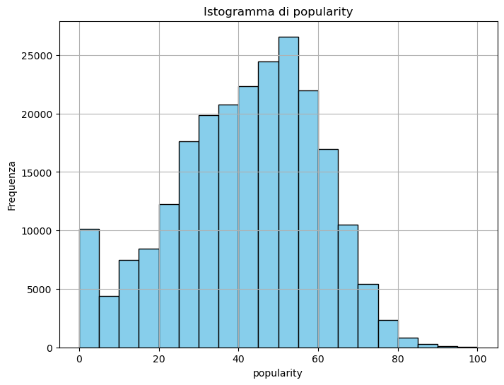

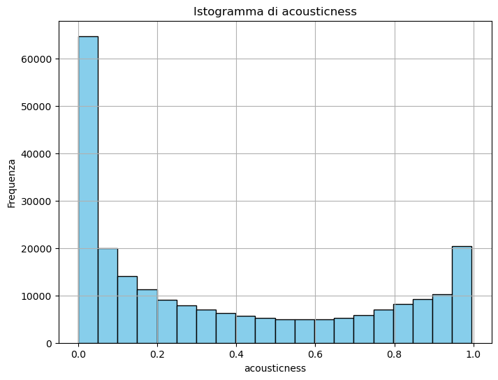

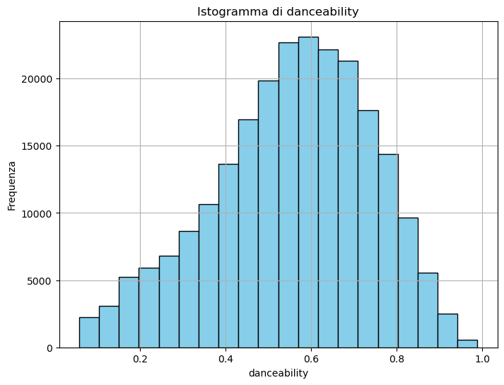

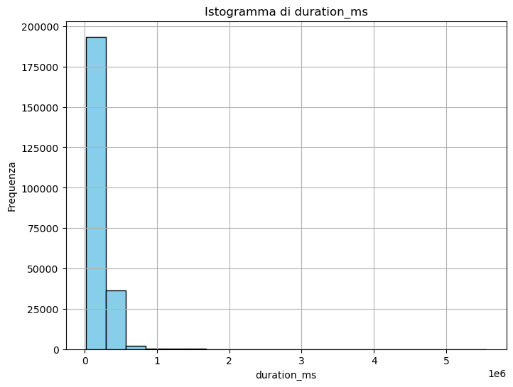

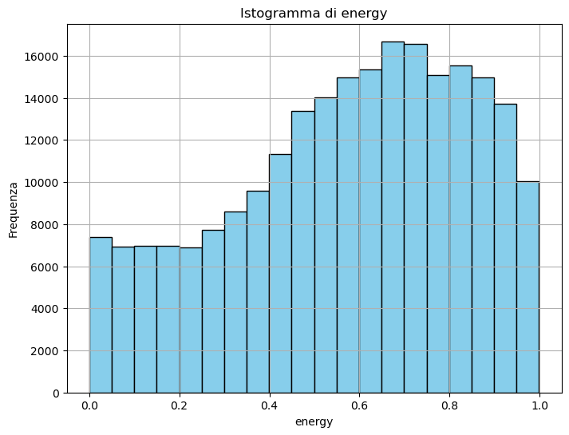

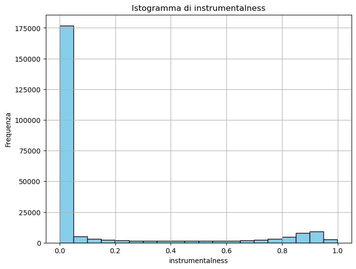

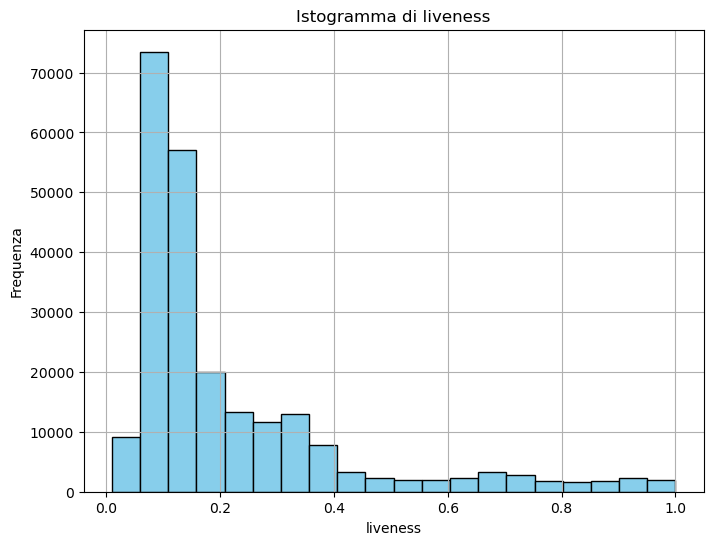

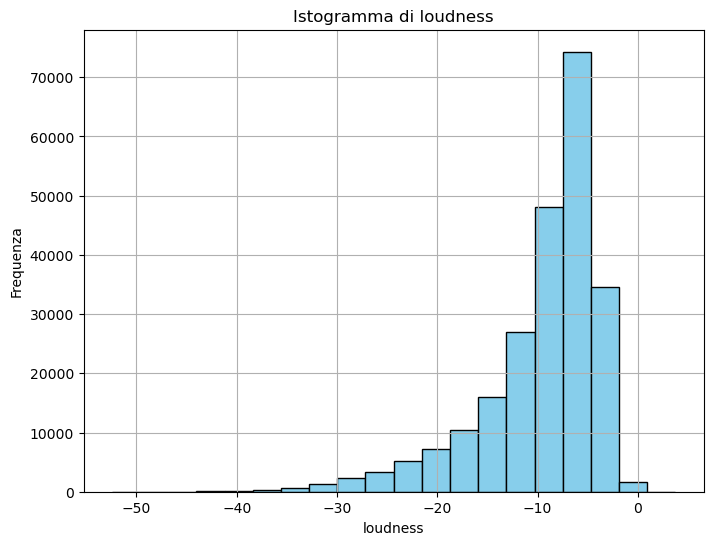

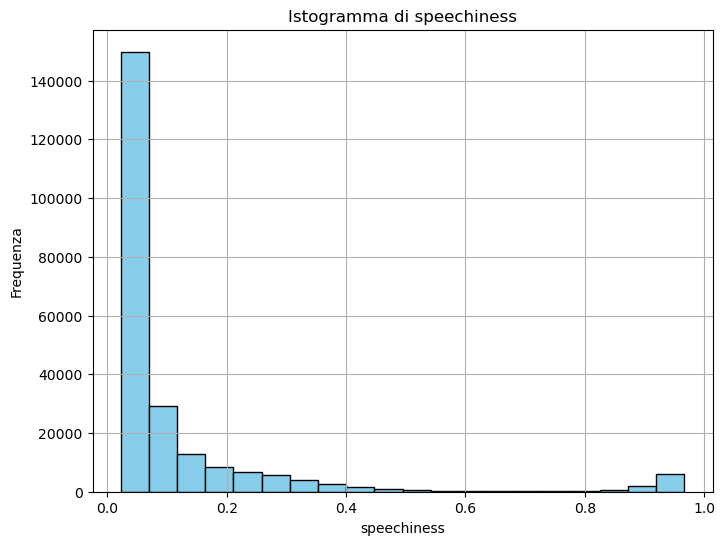

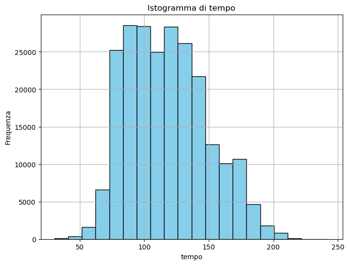

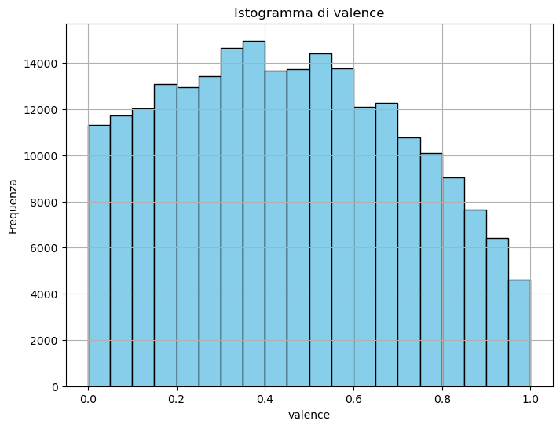

```python
num_columns = df.select_dtypes(include=['float64', 'int64']).columns

# Itera attraverso le colonne numeriche e crea un istogramma per ciascuna
for column in num_columns:
    plt.figure(figsize=(8, 6))
    df[column].plot(kind='hist', bins=20, color='skyblue', edgecolor='black')
    plt.title(f'Istogramma di {column}')
    plt.xlabel(column)
    plt.ylabel('Frequenza')
    plt.grid(True)
    plt.show()
```

Gli istogrammi mostrano la distribuzioni delle varie features: esistono features che si distribuiscono come una normale (popularity, danceability, tempo, valence) e altre sono più inclinate (speechiness, loudness, liveness, instrumentalness, duration). vediamo ora quali sono le canzoni più popolari (popularity > 80):

```python
popular_song = df[df['popularity'] > 80]
popular_song.head(10)
```

|  | genre | artist_name | track_name | track_id | popularity | acousticness | danceability | duration_ms | energy | instrumentalness | key | liveness | loudness | mode | speechiness | tempo | time_signature | valence |
| --- | --- | --- | --- | --- | --- | --- | --- | --- | --- | --- | --- | --- | --- | --- | --- | --- | --- | --- |
| 671 | Alternative | Joji | Sanctuary | 3xaugmCyXrVkrDTXbFkMW3 | 83 | 0.4220 | 0.552 | 180019 | 0.650 | 0.000275 | C# | 0.3720 | -7.199 | Major | 0.1280 | 167.788 | 4/4 | 0.316 |
| 672 | Alternative | Joji | SLOW DANCING IN THE DARK | 0rKtyWc8bvkriBthvHKY8d | 81 | 0.5440 | 0.515 | 209274 | 0.479 | 0.005980 | D# | 0.1910 | -7.458 | Major | 0.0261 | 88.964 | 4/4 | 0.284 |
| 9026 | Dance | Ariana Grande | break up with your girlfriend, i'm bored | 4kV4N9D1iKVxx1KLvtTpjS | 99 | 0.0421 | 0.726 | 190440 | 0.554 | 0.000000 | F | 0.1060 | -5.290 | Minor | 0.0917 | 169.999 | 4/4 | 0.335 |
| 9027 | Dance | Ariana Grande | 7 rings | 14msK75pk3pA33pzPVNtBF | 100 | 0.5780 | 0.725 | 178640 | 0.321 | 0.000000 | C# | 0.0884 | -10.744 | Minor | 0.3230 | 70.142 | 4/4 | 0.319 |
| 9028 | Dance | Halsey | Without Me | 5p7ujcrUXASCNwRaWNHR1C | 97 | 0.2970 | 0.752 | 201661 | 0.488 | 0.000009 | F# | 0.0936 | -7.050 | Major | 0.0705 | 136.041 | 4/4 | 0.533 |
| 9029 | Dance | Ariana Grande | needy | 1TEL6MlSSVLSdhOSddidlJ | 92 | 0.7800 | 0.647 | 171573 | 0.309 | 0.000007 | G | 0.2020 | -7.948 | Minor | 0.0366 | 87.045 | 4/4 | 0.195 |
| 9030 | Dance | Ariana Grande | NASA | 4uTvPEr01pjTbZgl7jcKBD | 91 | 0.4510 | 0.747 | 182000 | 0.458 | 0.000000 | F# | 0.2520 | -6.891 | Major | 0.3030 | 75.029 | 4/4 | 0.470 |
| 9031 | Dance | Ariana Grande | thank u, next | 2rPE9A1vEgShuZxxzR2tZH | 95 | 0.2800 | 0.724 | 207333 | 0.647 | 0.000000 | C# | 0.1020 | -5.642 | Major | 0.0658 | 106.960 | 4/4 | 0.435 |
| 9032 | Dance | Ariana Grande | bloodline | 2hloaUoRonYssMuqLCBLTX | 91 | 0.0815 | 0.758 | 216893 | 0.665 | 0.000157 | D | 0.2160 | -5.188 | Minor | 0.0774 | 151.976 | 4/4 | 0.643 |
| 9033 | Dance | Ariana Grande | bad idea | 5Il6Oe7lr5XM7A0cWbVQtr | 91 | 0.0268 | 0.847 | 267107 | 0.579 | 0.054500 | C# | 0.1020 | -5.314 | Major | 0.0719 | 137.998 | 4/4 | 0.569 |

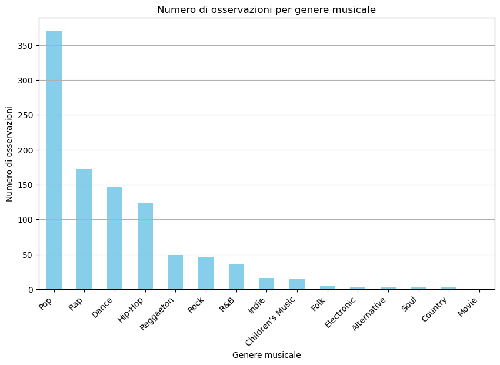

```python
cont_gen = popular_song['genre'].value_counts()

# Crea il plot a barre
plt.figure(figsize=(10, 6))
cont_gen.plot(kind='bar', color='skyblue')
plt.title('Numero di osservazioni per genere musicale')
plt.xlabel('Genere musicale')
plt.ylabel('Numero di osservazioni')
plt.xticks(rotation=45, ha='right')
plt.grid(axis='y')
plt.show()
```

le canzoni più popolari sono, in ordine quelle pop, rap, dance e hip-hop. penso che questa caratteristica possa essere utile per predirre il genere nel nostro modello.

# Analisi variabile dipendente

Dopo questa analisi preliminare, vedo come si distribuiscono le osservazioni per quanto riguarda il genere. Sarà la nostra variabile dipendente, quindi andiamo un po ad analizzarla:

```python
df['genre'].unique()
```

```
array(['Movie', 'R&B', 'A Capella', 'Alternative', 'Country', 'Dance',
       'Electronic', 'Anime', 'Folk', 'Blues', 'Opera', 'Hip-Hop',
       "Children's Music", 'Children’s Music', 'Rap', 'Indie',
       'Classical', 'Pop', 'Reggae', 'Reggaeton', 'Jazz', 'Rock', 'Ska',
       'Comedy', 'Soul', 'Soundtrack', 'World'], dtype=object)
```

la variabile può assumere 27 valori, ma occhio: ci sono due valori uguali ma scritti diversamente: . priima di visualizzarla sistemo il problema dei due valori sbagliati

```python
df['genre'] = df['genre'].replace({"Children’s Music": "Children's Music"})
```

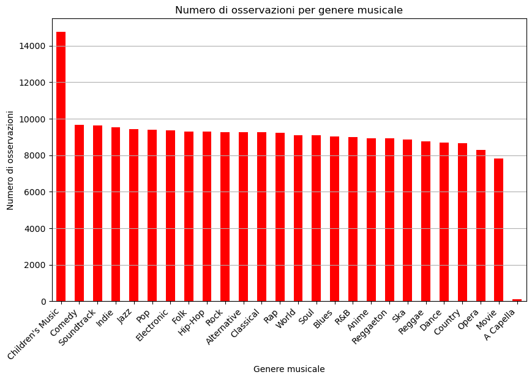

```python
numero_generi = df['genre'].value_counts()

# Crea il plot a barre
plt.figure(figsize=(10, 6))
numero_generi.plot(kind='bar', color='red')
plt.title('Numero di osservazioni per genere musicale')
plt.xlabel('Genere musicale')
plt.ylabel('Numero di osservazioni')
plt.xticks(rotation=45, ha='right')
plt.grid(axis='y')
plt.show()
```

```python
print(numero_generi)
```

```
genre
Children's Music    14756
Comedy               9681
Soundtrack           9646
Indie                9543
Jazz                 9441
Pop                  9386
Electronic           9377
Folk                 9299
Hip-Hop              9295
Rock                 9272
Alternative          9263
Classical            9256
Rap                  9232
World                9096
Soul                 9089
Blues                9023
R&B                  8992
Anime                8936
Reggaeton            8927
Ska                  8874
Reggae               8771
Dance                8701
Country              8664
Opera                8280
Movie                7806
A Capella             119
Name: count, dtype: int64
```

Ci sono troppi valori per genere, cerchiamo prima di fare un subset selezionando 3 tipi diversi di generi musicali e addestriamo un modello: usiamo i generi opera, pop e rock

```python
#print
sub_df=df.loc[df['genre'].isin(['Opera','Pop','Rock'])]
sub_df
```

|  | genre | artist_name | track_name | track_id | popularity | acousticness | danceability | duration_ms | energy | instrumentalness | key | liveness | loudness | mode | speechiness | tempo | time_signature | valence |
| --- | --- | --- | --- | --- | --- | --- | --- | --- | --- | --- | --- | --- | --- | --- | --- | --- | --- | --- |
| 57582 | Opera | Charles Gounod | Ave Maria | 2kyEgPaAW8wdpvevPnkf0Z | 62 | 0.9930 | 0.1320 | 163267 | 0.0195 | 0.888000 | C | 0.0569 | -29.760 | Major | 0.0445 | 81.616 | 3/4 | 0.1400 |
| 57583 | Opera | Richard Wagner | Tannhäuser: Overture | 1U1i1HBJ5H8DY5J4fO8ySg | 58 | 0.8310 | 0.0843 | 853827 | 0.1820 | 0.926000 | E | 0.1970 | -15.880 | Major | 0.0356 | 73.750 | 4/4 | 0.0604 |
| 57584 | Opera | Giacomo Puccini | "Nessun dorma!" | 74WjYdm3Lvbwnds4thYPUU | 63 | 0.9610 | 0.1710 | 180933 | 0.3080 | 0.005460 | D | 0.3190 | -12.383 | Major | 0.0456 | 171.798 | 5/4 | 0.0889 |
| 57585 | Opera | Gioachino Rossini | Semiramide: Overture (Live) | 2wG5UNal67Vkyjsdm3Ahat | 2 | 0.8960 | 0.2590 | 746600 | 0.1980 | 0.679000 | A | 0.6890 | -19.621 | Major | 0.0658 | 158.284 | 4/4 | 0.1590 |
| 57586 | Opera | Gioachino Rossini | Overture (Sinfonia) | 1chTrqszWQEOP4RsNuOZf7 | 52 | 0.9110 | 0.3390 | 425000 | 0.1400 | 0.678000 | E | 0.1570 | -20.598 | Major | 0.0470 | 95.975 | 4/4 | 0.2960 |
| ... | ... | ... | ... | ... | ... | ... | ... | ... | ... | ... | ... | ... | ... | ... | ... | ... | ... | ... |
| 226503 | Rock | The Beatles | No Reply - Remastered 2009 | 4ltC6PrqkTtpcRNi5lvS4z | 58 | 0.6700 | 0.7180 | 136067 | 0.5930 | 0.000000 | C | 0.1720 | -9.976 | Major | 0.0377 | 124.251 | 4/4 | 0.8690 |
| 226504 | Rock | QUEEN BEE | Fire | 3xVCQGla5LLhrwqNS2FcHo | 60 | 0.0340 | 0.5210 | 215973 | 0.9330 | 0.000021 | B | 0.3300 | -4.874 | Minor | 0.1790 | 169.842 | 4/4 | 0.6070 |
| 226505 | Rock | Freedom Fry | Awake | 47ed9eO66cBHvWteLlF7C0 | 59 | 0.6710 | 0.6180 | 194000 | 0.7690 | 0.241000 | B | 0.2760 | -4.642 | Minor | 0.0309 | 111.978 | 4/4 | 0.6070 |
| 226506 | Rock | Beck | Girl | 3DgNj1aYbSRVoVO8yX7DRt | 51 | 0.0543 | 0.6810 | 209893 | 0.6620 | 0.005120 | G# | 0.2060 | -6.526 | Major | 0.1150 | 149.485 | 4/4 | 0.8500 |
| 226507 | Rock | Cage The Elephant | How Are You True | 6vcdiwrCVXnTLASFdjEV8r | 55 | 0.3850 | 0.4930 | 280947 | 0.4610 | 0.000333 | B | 0.0985 | -9.777 | Minor | 0.0336 | 140.049 | 4/4 | 0.2860 |

26938 rows × 18 columns

```python
sub_df['genre'].unique()
```

```
array(['Opera', 'Pop', 'Rock'], dtype=object)
```

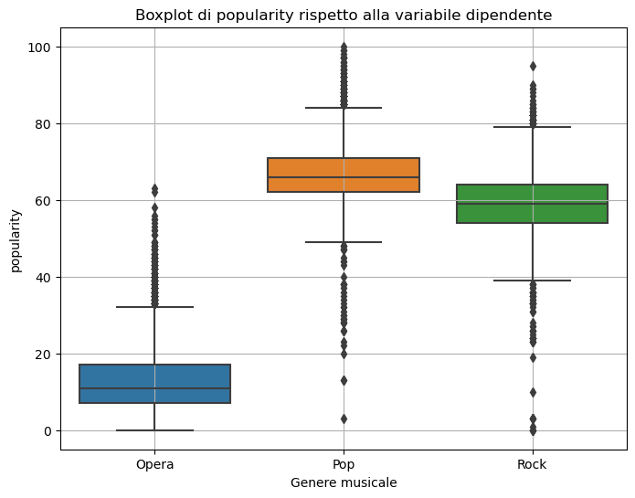

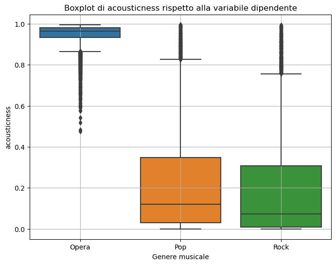

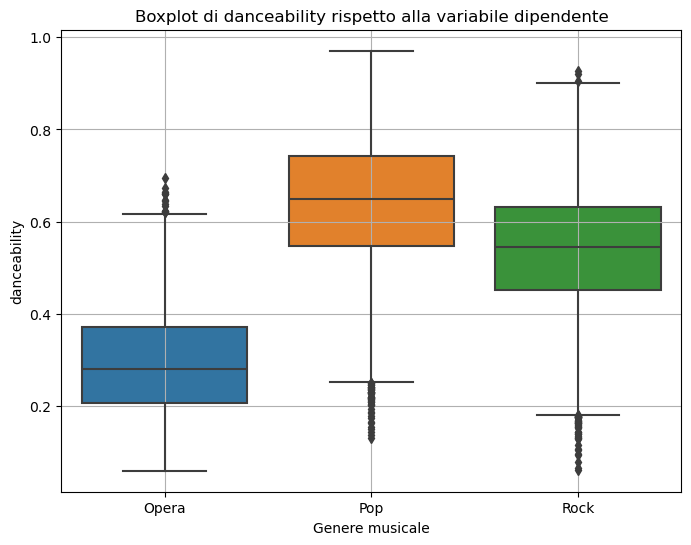

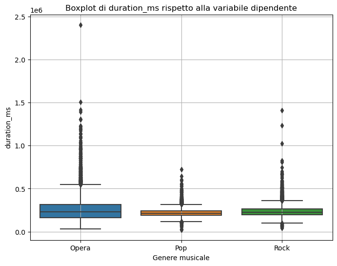

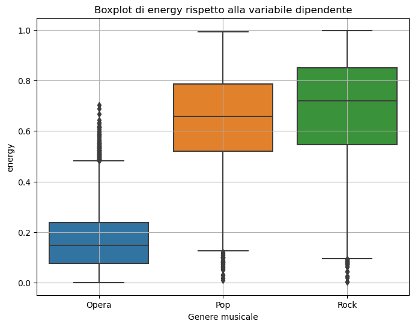

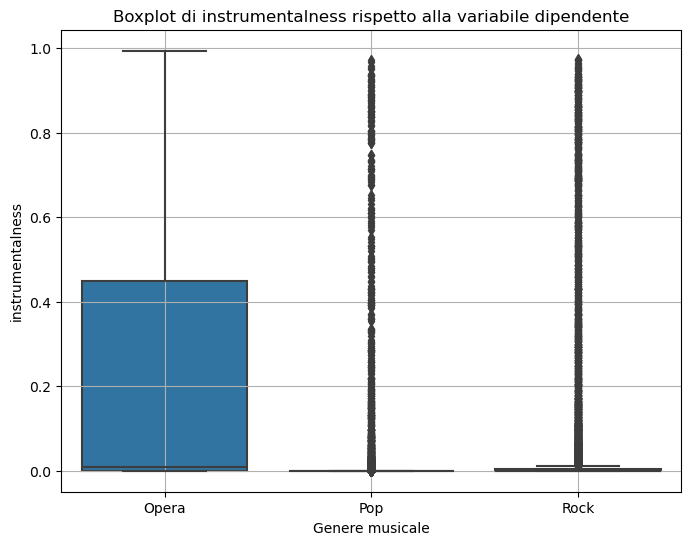

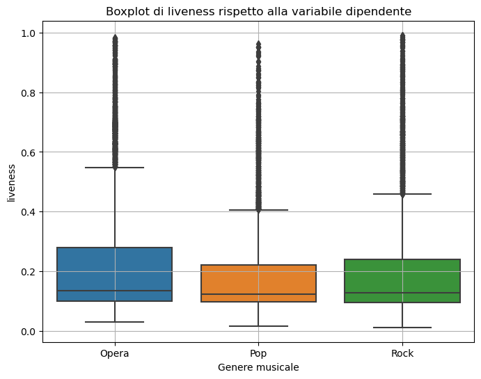

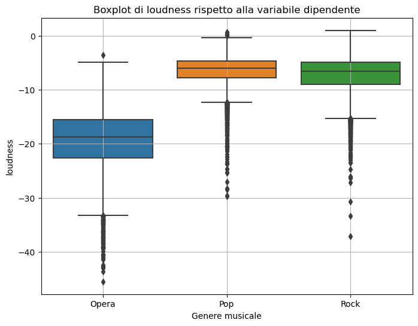

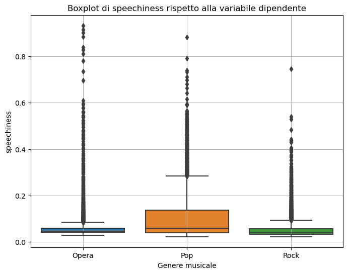

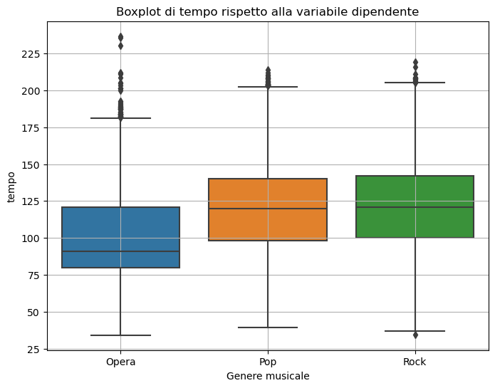

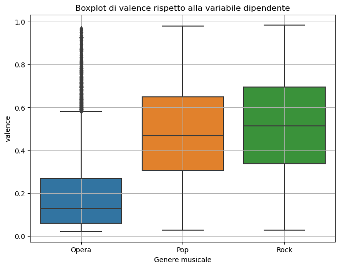

```python
colonne_numeriche = df.select_dtypes(include=['float64', 'int64']).columns
for column in colonne_numeriche:
    plt.figure(figsize=(8, 6))
    sns.boxplot(x='genre', y=column, data=sub_df)
    plt.title(f'Boxplot di {column} rispetto alla variabile dipendente')
    plt.xlabel('Genere musicale')
    plt.ylabel(column)
    plt.grid(True)
    plt.show()
```

Ora dividiamo il dataset in due differenti df: il test e il train set. per il modello che voglio addestrare userò la variabile genere come dipendente e le features (popularity, acousticness, danceability, energy, instrumentalness, liveness, loudness, speechiness, tempo and valence). prima di tutto costruisco dei boxplot per vedere quali sono le features che hanno maggiore impatto, con lo scopo di tenere quelle migliori secondo me.

popularity, acousticness, danceability, energy, instrumentalness, loudness, tempo, speechiness, valence le teniamo duration_ms, liveness, troppo simili i valori medi, possiamo decidere di eliminarle.

# Modelli di classificazione

```python
from sklearn.model_selection import train_test_split

train, test = train_test_split(sub_df, test_size=0.2)
```

```python
train.shape
```

```
(21550, 18)
```

```python
test.shape
```

```
(5388, 18)
```

selezioniamo le variabili

```python
# Variabili dipendenti (y)
y_train = train['genre']
y_test = test['genre']

# Variabili indipendenti (X)
X_train = train.drop(columns=['genre', 'artist_name', 'track_name', 'track_id', 'duration_ms', 'liveness', 'key', 'mode', 'time_signature'])
X_test = test.drop(columns=['genre', 'artist_name', 'track_name', 'track_id', 'duration_ms', 'liveness', 'key', 'mode', 'time_signature'])
```

```python
X_test
```

|  | popularity | acousticness | danceability | energy | instrumentalness | loudness | speechiness | tempo | valence |
| --- | --- | --- | --- | --- | --- | --- | --- | --- | --- |
| 80524 | 16 | 0.98200 | 0.385 | 0.1340 | 0.003060 | -20.614 | 0.0616 | 115.215 | 0.0398 |
| 149334 | 59 | 0.79100 | 0.465 | 0.2690 | 0.000008 | -12.140 | 0.0311 | 131.391 | 0.1840 |
| 108957 | 72 | 0.33600 | 0.481 | 0.4510 | 0.000000 | -6.095 | 0.0347 | 157.966 | 0.2890 |
| 154223 | 62 | 0.00190 | 0.368 | 0.9060 | 0.000000 | -2.892 | 0.1010 | 177.956 | 0.6920 |
| 109921 | 68 | 0.29400 | 0.628 | 0.5530 | 0.005510 | -8.967 | 0.0472 | 140.026 | 0.3670 |
| ... | ... | ... | ... | ... | ... | ... | ... | ... | ... |
| 224151 | 60 | 0.03510 | 0.601 | 0.8590 | 0.331000 | -6.311 | 0.0397 | 101.003 | 0.4310 |
| 107520 | 5 | 0.98800 | 0.210 | 0.0633 | 0.000061 | -19.728 | 0.0553 | 171.853 | 0.0400 |
| 224195 | 63 | 0.32300 | 0.386 | 0.6750 | 0.000004 | -5.481 | 0.0424 | 189.894 | 0.4290 |
| 81686 | 14 | 0.96900 | 0.399 | 0.2840 | 0.000450 | -17.031 | 0.0987 | 137.763 | 0.2030 |
| 110320 | 65 | 0.00125 | 0.564 | 0.7100 | 0.000000 | -4.920 | 0.0461 | 91.972 | 0.3930 |

5388 rows × 9 columns

```python
X_train
```

|  | popularity | acousticness | danceability | energy | instrumentalness | loudness | speechiness | tempo | valence |
| --- | --- | --- | --- | --- | --- | --- | --- | --- | --- |
| 150360 | 67 | 0.0056 | 0.623 | 0.680 | 0.000425 | -13.255 | 0.0282 | 129.713 | 0.7370 |
| 149957 | 59 | 0.4870 | 0.534 | 0.659 | 0.080800 | -8.279 | 0.0270 | 107.052 | 0.4970 |
| 222360 | 63 | 0.8270 | 0.210 | 0.233 | 0.003900 | -11.636 | 0.0287 | 88.679 | 0.0950 |
| 150586 | 68 | 0.9210 | 0.650 | 0.171 | 0.000000 | -9.005 | 0.0519 | 119.522 | 0.2840 |
| 79683 | 21 | 0.9890 | 0.329 | 0.120 | 0.006540 | -17.790 | 0.0536 | 88.904 | 0.0579 |
| ... | ... | ... | ... | ... | ... | ... | ... | ... | ... |
| 105608 | 4 | 0.9530 | 0.230 | 0.257 | 0.070600 | -21.101 | 0.0600 | 88.829 | 0.1180 |
| 154763 | 51 | 0.3260 | 0.536 | 0.567 | 0.000019 | -7.512 | 0.1130 | 82.191 | 0.4330 |
| 57756 | 38 | 0.9550 | 0.345 | 0.226 | 0.000001 | -10.217 | 0.0378 | 67.993 | 0.1860 |
| 112402 | 65 | 0.0290 | 0.840 | 0.621 | 0.000002 | -5.928 | 0.2060 | 141.032 | 0.3320 |
| 149179 | 63 | 0.0605 | 0.591 | 0.831 | 0.000047 | -5.647 | 0.0415 | 144.084 | 0.7050 |

21550 rows × 9 columns

```python
from sklearn.ensemble import RandomForestClassifier
from sklearn.metrics import accuracy_score, classification_report

# costruire il modello
model_random_forest = RandomForestClassifier(n_estimators=500, random_state=42, bootstrap=True)
model_random_forest.fit(X_train, y_train)
```

```
RandomForestClassifier(n_estimators=500, random_state=42)
```

```python
#predizioni sul test set
y_pred_RF = model_random_forest.predict(X_test)
y_pred_RF
```

```
array(['Opera', 'Rock', 'Pop', ..., 'Pop', 'Opera', 'Pop'], dtype=object)
```

Usando la funzione qui sopra sono in grado di predirre sul test set le categorie. il risultato è un vettore con specificata la categoria predetta dal mio modello.

```python
#uso la funzione predict_proba per vedere le probabilità che una osservazione appartenga ad una categoria o un'altra
y_pred_prob=model_random_forest.predict_proba(X_test)
```

Ora vediamo invece l'importanza di ogni features:

```python
importances = model_random_forest.feature_importances_
columns = X_test.columns
i=0

while i < len(columns):
    print(f"l'importanza della feature '{columns[i]}' is is {round(importances[i] * 100, 2)}%.")
    i += 1
```

```
l'importanza della feature 'popularity' is is 33.2%.
l'importanza della feature 'acousticness' is is 18.05%.
l'importanza della feature 'danceability' is is 9.74%.
l'importanza della feature 'energy' is is 8.71%.
l'importanza della feature 'instrumentalness' is is 4.27%.
l'importanza della feature 'loudness' is is 10.56%.
l'importanza della feature 'speechiness' is is 7.58%.
l'importanza della feature 'tempo' is is 3.21%.
l'importanza della feature 'valence' is is 4.67%.
```

Accuracy Score: Misura la frazione di predizioni corrette rispetto al totale delle predizioni.

```python
from sklearn.metrics import accuracy_score
accuracy_RF = accuracy_score(y_test, y_pred_RF)
accuracy_RF
```

```
0.8071640682999257
```

Il modello ha una accuratezza dell'80%

Classification Report: Fornisce una panoramica delle metriche di classificazione, tra cui precision, recall, F1-score e support.

```python
from sklearn.metrics import classification_report
report_RF = classification_report(y_test, y_pred_RF)
report_RF
```

[output not shown]

Confusion Matrix: Mostra il numero di predizioni corrette e errate per ciascuna classe.

```python
from sklearn.metrics import confusion_matrix
matrix_RF = confusion_matrix(y_test, y_pred_RF)
matrix_RF
```

```
array([[1658,    1,    6],
       [   0, 1340,  484],
       [   3,  545, 1351]], dtype=int64)
```

```python
print("Accuracy:", accuracy_RF)
print("Matrix:")
print(matrix_RF)
print("Classification Report:")
print(report_RF)
```

```
Accuracy: 0.8071640682999257
Matrix:
[[1658    1    6]
 [   0 1340  484]
 [   3  545 1351]]
Classification Report:
              precision    recall  f1-score   support

       Opera       1.00      1.00      1.00      1665
         Pop       0.71      0.73      0.72      1824
        Rock       0.73      0.71      0.72      1899

    accuracy                           0.81      5388
   macro avg       0.81      0.81      0.81      5388
weighted avg       0.81      0.81      0.81      5388
```

Il modello è in grado di predirre molto bene la categoria opera (f1-score di 1). Fa un po fatica con le categorie Pop e Rock come mostrato dalla confusion matrix e dal f1-score(0.72 per entrambi)

Tramite la libreria scikit-learn (https://towardsdatascience.com/hyperparameter-tuning-the-random-forest-in-python-using-scikit-learn-28d2aa77dd74). ho sviluppato una funzione per trovare la migliore combinazione di hyperparameter (in questo caso numero degli estimatori, max depth, divisione del dataset e min samples leaf) altri possibili argomenti da esplorare potrebbero essere bootstrap=True o False e max_features=auto o sqrt. in ogni caso con questa funzione vengono stimati 6 * 6 * 3 * 3=324 modelli diversi per trovare la combinazione più accurata.

```python
from sklearn.ensemble import RandomForestClassifier
from sklearn.model_selection import GridSearchCV

def ricerca_iperparametri_random_forest(X_train, y_train):
    """
    Esegue la ricerca degli iperparametri per il modello Random Forest.

    Argomenti:
    X_train (DataFrame): Variabili indipendenti di addestramento.
    y_train (Series): Variabile dipendente di addestramento.

    Restituisce:
    RandomForestClassifier: Modello Random Forest ottimizzato con i migliori iperparametri.
    """
    # Definisci la griglia degli iperparametri da esplorare
    parametri_grid = {
        'n_estimators': [200, 300, 500, 700, 900, 1100],
        'max_depth': [None, 10, 20, 30, 40, 50],
        'min_samples_split': [2, 5, 10],
        'min_samples_leaf': [1, 2, 4]
    }

    # Inizializza il modello Random Forest
    random_forest_model = RandomForestClassifier(random_state=42)

    # Inizializza la ricerca degli iperparametri utilizzando la cross-validation a 5 fold
    grid_search = GridSearchCV(estimator=random_forest_model, param_grid=parametri_grid, cv=5, scoring='accuracy')

    # Esegui la ricerca degli iperparametri
    grid_search.fit(X_train, y_train)

    # Ottieni il modello ottimizzato con i migliori iperparametri
    modello_ottimizzato = grid_search.best_estimator_

    # Stampa i migliori iperparametri trovati
    print("Migliori iperparametri:")
    print(grid_search.best_params_)

    return modello_ottimizzato
```

```python
#ricerca_iperparametri_random_forest(X_train, y_train) non lancio il comando, troppo tempo di calcolo.
```

# Naive Bayes classifier

Il secondo modello che vorrei sviluppare è il Naive Bayes Classifier: per farlo usero la funzione GaussianNB dalla libreria sklearn:

```python
from sklearn.naive_bayes import GaussianNB
from sklearn.metrics import accuracy_score, classification_report

#creo il modello
naive_bayes_model = GaussianNB() #di solito non è necessario impostare alcun parametro oltre a priors (ma viene stimato sui dati direttamente).
#Non aggiungo alcun parametro

#lo addestro sui dati train
naive_bayes_model.fit(X_train, y_train)
```

```
GaussianNB()
```

```python
# 3. Effettua le previsioni sul DataFrame di test
y_pred_NB = naive_bayes_model.predict(X_test)

# 4. Valuta le prestazioni del modello
accuracy_NB = accuracy_score(y_test, y_pred_NB)
report_NB = classification_report(y_test, y_pred_NB)
matrix_NB = confusion_matrix(y_test, y_pred_RF)

print("Accuracy:", accuracy_NB)
print("Matrix:")
print(matrix_NB)
print("Classification Report:")
print(report_NB)
```

```
Accuracy: 0.8220118782479584
Matrix:
[[1658    1    6]
 [   0 1340  484]
 [   3  545 1351]]
Classification Report:
              precision    recall  f1-score   support

       Opera       0.99      1.00      0.99      1665
         Pop       0.75      0.72      0.73      1824
        Rock       0.74      0.77      0.76      1899

    accuracy                           0.82      5388
   macro avg       0.83      0.83      0.83      5388
weighted avg       0.82      0.82      0.82      5388
```

L'accuratezza di questo modello è del 2% più alta, arrivando all'82%. Gli F1 score delle categorie Pop e Rock sono un po più alti rispetto a quelli del modello precedente.

# Support Vector Machine

L'ultimo modello che svilupperò è il Support Vector Machine. Il primo sarà linear mentre il secondo sarà polinomiale. La differenza principale tra questi due modelli è che, mentre un modello lineare è adatto per dati con relazioni lineari, uno polinomiale è in grado di modellare relazioni più complesse, adattandosi meglio a dati che non possono essere separati linearmente.

Modello lineare:

```python
from sklearn.svm import SVC

# creo il modello
svm_linear_model = SVC(kernel='linear')

# 2. Addestra il modello sul DataFrame di addestramento
svm_linear_model.fit(X_train, y_train)
```

```
SVC(kernel='linear')
```

```python
# previsione sul test set
y_linearSVM_pred = svm_linear_model.predict(X_test)

# 4. Valuta le prestazioni del modello
accuracy_linearSVM = accuracy_score(y_test, y_linearSVM_pred)
report_linearSVM = classification_report(y_test, y_linearSVM_pred)
matrix__linearSVM = confusion_matrix(y_test, y_linearSVM_pred)
print("Accuracy:", accuracy_linearSVM)
print("Matrix:")
print(matrix__linearSVM)
print("Classification Report:")
print(report_linearSVM)
```

```
Accuracy: 0.8368596881959911
Matrix:
[[1659    0    6]
 [   0 1372  452]
 [   5  416 1478]]
Classification Report:
              precision    recall  f1-score   support

       Opera       1.00      1.00      1.00      1665
         Pop       0.77      0.75      0.76      1824
        Rock       0.76      0.78      0.77      1899

    accuracy                           0.84      5388
   macro avg       0.84      0.84      0.84      5388
weighted avg       0.84      0.84      0.84      5388
```

Modello polinomiale:

```python
# specifica del modello
svm_poly_model = SVC(kernel='poly', degree=3)

# addestro coi dati train
svm_poly_model.fit(X_train, y_train)
```

```
SVC(kernel='poly')
```

```python
# previsione sul test set
y_polySVM_pred = svm_linear_model.predict(X_test)

# 4. Valuta le prestazioni del modello
accuracy_polySVM = accuracy_score(y_test, y_polySVM_pred)
report_polySVM = classification_report(y_test, y_polySVM_pred)
matrix__polySVM = confusion_matrix(y_test, y_polySVM_pred)
print("Accuracy:", accuracy_polySVM)
print("Matrix:")
print(matrix__polySVM)
print("Classification Report:")
print(report_polySVM)
```

```
Accuracy: 0.8368596881959911
Matrix:
[[1659    0    6]
 [   0 1372  452]
 [   5  416 1478]]
Classification Report:
              precision    recall  f1-score   support

       Opera       1.00      1.00      1.00      1665
         Pop       0.77      0.75      0.76      1824
        Rock       0.76      0.78      0.77      1899

    accuracy                           0.84      5388
   macro avg       0.84      0.84      0.84      5388
weighted avg       0.84      0.84      0.84      5388
```

```python
from sklearn.svm import SVC
from sklearn.model_selection import GridSearchCV

def ricerca_iperparametri_svm(X_train, y_train):
    """
    Esegue la ricerca degli iperparametri per il modello Support Vector Machine (SVM).

    Argomenti:
    X_train (DataFrame): Variabili indipendenti di addestramento.
    y_train (Series): Variabile dipendente di addestramento.

    Restituisce:
    SVC: Modello SVM ottimizzato con i migliori iperparametri.
    """
    # Definisci la griglia degli iperparametri da esplorare
    parametri_grid = {
        'C': [0.1, 1, 10],
        'kernel': ['linear', 'poly'],
        'gamma': ['scale', 'auto'],
        'degree': [2, 3, 4],
    }

    # Inizializza il modello SVM
    svm_model = SVC(random_state=42)

    # Inizializza la ricerca degli iperparametri utilizzando la cross-validation a 5 fold
    grid_search = GridSearchCV(estimator=svm_model, param_grid=parametri_grid, cv=5, scoring='accuracy')

    # Esegui la ricerca degli iperparametri
    grid_search.fit(X_train, y_train)

    # Ottieni il modello ottimizzato con i migliori iperparametri
    modello_ottimizzato = grid_search.best_estimator_

    # Stampa i migliori iperparametri trovati
    print("Migliori iperparametri:")
    print(grid_search.best_params_)

    return modello_ottimizzato
```

```python
def mostra_grafico_accuratezza_scatter(accuratezza_svm_linear, accuratezza_svm_poly, accuratezza_rf, accuratezza_nb):
    """
    Mostra un grafico a dispersione delle accuratezze dei modelli SVM (lineare e polinomiale), Random Forest e Naive Bayes.

    Argomenti:
    accuratezza_svm_linear (float): Accuratezza del modello SVM lineare.
    accuratezza_svm_poly (float): Accuratezza del modello SVM polinomiale.
    accuratezza_rf (float): Accuratezza del modello Random Forest.
    accuratezza_nb (float): Accuratezza del modello Naive Bayes.
    """
    # Etichette per i modelli
    modelli = ['SVM linear', 'SVM poly', 'Random Forest', 'Naive Bayes']

    # Accuratezze
    accuratezze = [accuratezza_svm_linear, accuratezza_svm_poly, accuratezza_rf, accuratezza_nb]

    # Creazione del grafico a dispersione
    plt.figure(figsize=(8, 6))
    plt.scatter(accuratezze, modelli, color='blue', marker='o', s=100)  # s è la dimensione del marker
    plt.xlabel('Accuratezza')
    plt.ylabel('Modelli')
    plt.title('Accuratezza dei modelli di classificazione')
    plt.xlim(0.75, 0.9)  # Imposta il limite dell'asse x da 0 a 1 per l'accuratezza
    plt.grid(True)  # Aggiunge la griglia
    plt.show()
```

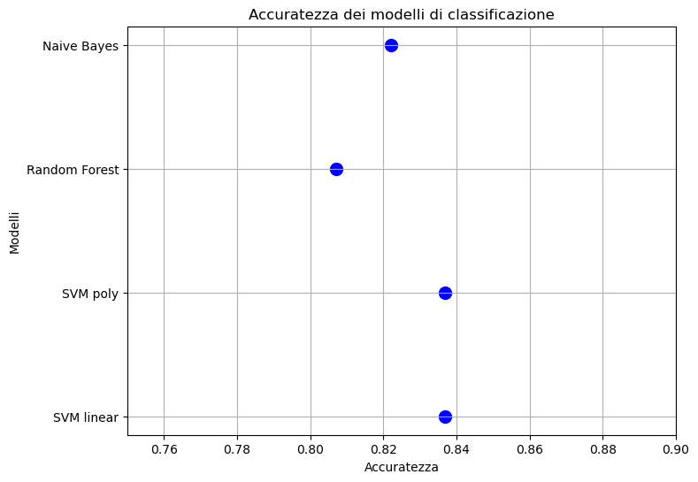

```python
mostra_grafico_accuratezza_scatter(accuracy_linearSVM, accuracy_polySVM, accuracy_RF, accuracy_NB)
```